# analise_exploratoria_final

devjaynemorais

4 de julho de 2019

```
Observations: 72,887
Variables: 7
$ id              <dbl> 0, 1, 2, 3, 4, 5, 6, 7, 8, 9, 10, 11, 12, 13, 14, 15, 16, 17, 18, 19, 20, 21, 22…
$ confidence      <dbl> 0.973732, 0.778390, 0.785304, 0.806714, 0.673818, 0.629125, 0.573629, 0.519566, …
$ file_name       <chr> "/home/jayne/darknet/VOCdevkit/VOC2007/JPEGImages/000001.jpg", "/home/jayne/dark…
$ frame_id        <dbl> 1, 1, 2, 4, 4, 4, 4, 4, 4, 4, 5, 5, 5, 6, 7, 7, 8, 8, 9, 9, 10, 10, 10, 11, 11, …
$ object_class_id <dbl> 14, 11, 18, 6, 6, 6, 6, 6, 6, 6, 10, 8, 8, 8, 14, 12, 11, 7, 16, 9, 6, 6, 5, 14,…
$ object_name     <chr> "person", "dog", "train", "car", "car", "car", "car", "car", "car", "car", "dini…
$ resolution      <dbl> 288, 288, 288, 288, 288, 288, 288, 288, 288, 288, 288, 288, 288, 288, 288, 288, …
```

[output not shown]

| id | confidence | file_name | frame_id | object_class_id | object_name | resolution |
| --- | --- | --- | --- | --- | --- | --- |
| 0 | 0.973732 | /home/jayne/darknet/VOCdevkit/VOC2007/JPEGImages/000001.jpg | 1 | 14 | person | 288 |
| 1 | 0.778390 | /home/jayne/darknet/VOCdevkit/VOC2007/JPEGImages/000001.jpg | 1 | 11 | dog | 288 |
| 2 | 0.785304 | /home/jayne/darknet/VOCdevkit/VOC2007/JPEGImages/000002.jpg | 2 | 18 | train | 288 |
| 3 | 0.806714 | /home/jayne/darknet/VOCdevkit/VOC2007/JPEGImages/000004.jpg | 4 | 6 | car | 288 |
| 4 | 0.673818 | /home/jayne/darknet/VOCdevkit/VOC2007/JPEGImages/000004.jpg | 4 | 6 | car | 288 |
| 5 | 0.629125 | /home/jayne/darknet/VOCdevkit/VOC2007/JPEGImages/000004.jpg | 4 | 6 | car | 288 |
| 6 | 0.573629 | /home/jayne/darknet/VOCdevkit/VOC2007/JPEGImages/000004.jpg | 4 | 6 | car | 288 |
| 7 | 0.519566 | /home/jayne/darknet/VOCdevkit/VOC2007/JPEGImages/000004.jpg | 4 | 6 | car | 288 |
| 8 | 0.489446 | /home/jayne/darknet/VOCdevkit/VOC2007/JPEGImages/000004.jpg | 4 | 6 | car | 288 |
| 9 | 0.294033 | /home/jayne/darknet/VOCdevkit/VOC2007/JPEGImages/000004.jpg | 4 | 6 | car | 288 |

[output cut: 990 more lines]

Análise

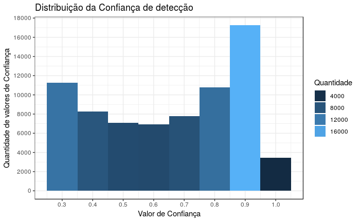

```r
#dados %>%
   # ggplot(aes(x = confidence)) +
   # geom_density(alpha=0.55) +
   # scale_x_continuous(breaks = seq(from = 0, to = 1, by = 0.1))  +
   # scale_y_continuous(breaks = seq(from = 0, to = 30000, by = 2000)) +
   # labs(
      #    title = "Distribuição da confiança de detecção",
      #    y = "Quantidade de valores de Confiança",
      #    x = "Valor de Confiança"
     # )
dados %>%
    ggplot(aes(x = confidence)) +
    geom_histogram(binwidth = 0.1, aes(fill = ..count..) ) +
    scale_x_continuous(breaks = seq(from = 0, to = 1, by = 0.1))  +
    scale_y_continuous(breaks = seq(from = 0, to = 30000, by = 2000)) +
    labs(
        title = "Distribuição da Confiança de detecção",
        y = "Quantidade de valores de Confiança",
        x = "Valor de Confiança"
    )+ guides(fill=guide_legend("Quantidade"))
ggsave("explora_dados_de_confianca.pdf", width = 5 , height = 4)
```

```r
NA
```

```r
dados %>%
    group_by(resolution) %>%
    summarise(media_confidence = mean(confidence))
```

| resolution | media_confidence |
| --- | --- |
| 288 | 0.6305757 |
| 352 | 0.6452817 |
| 416 | 0.6555912 |
| 480 | 0.6581578 |
| 544 | 0.6583101 |

```r
dados %>%
    group_by(object_name, resolution) %>%
    summarise(media_confidence = mean(confidence))
```

| object_name | resolution | media_confidence |
| --- | --- | --- |
| aeroplane | 288 | 0.6533771 |
| aeroplane | 352 | 0.6670147 |
| aeroplane | 416 | 0.6714091 |
| aeroplane | 480 | 0.6685480 |
| aeroplane | 544 | 0.6729533 |
| bicycle | 288 | 0.7085457 |
| bicycle | 352 | 0.7155024 |
| bicycle | 416 | 0.7355661 |
| bicycle | 480 | 0.7455788 |
| bicycle | 544 | 0.7330700 |

[output cut: 90 more lines]

```r
NA
```

## Com ICs

```r
theta_confianca = function(d, i){
    confiancas = d %>%
        slice(i) %>%
        summarise(media_confianca = mean(confidence))

    fpcc = confiancas %>% pull(media_confianca)

    fpcc
}
theta_c_fds = theta_confianca(dados, 1:NROW(dados))
theta_c_fds
```

```
[1] 0.6502283
```

```r
library(boot)
booted <- boot(data = dados,
               statistic = theta_confianca,
               R = 2000)
```

```r
ci = tidy(booted,
          conf.level = 0.95,
          conf.int = TRUE)
```

```r
glimpse(ci)
```

```
Observations: 1
Variables: 5
$ statistic <dbl> 0.6502283
$ bias      <dbl> 1.612462e-05
$ std.error <dbl> 0.0008331605
$ conf.low  <dbl> 0.6485623
$ conf.high <dbl> 0.6518875
```

```
Observations: 100
Variables: 6
$ class_id   <dbl> 0, 1, 2, 3, 4, 5, 6, 7, 8, 9, 10, 11, 12, 13, 14, 15, 16, 17, 18, 19, 0, 1, 2, 3, 4, …
$ class_name <chr> "aeroplane", "bicycle", "bird", "boat", "bottle", "bus", "car", "cat", "chair", "cow"…
$ ap         <dbl> 69.43, 75.30, 64.77, 60.67, 35.29, 78.03, 76.52, 85.88, 44.82, 69.43, 71.78, 80.59, 8…
$ tp         <dbl> 194, 237, 295, 163, 181, 158, 915, 288, 387, 175, 152, 384, 275, 246, 3051, 217, 157,…
$ fp         <dbl> 113, 79, 166, 132, 160, 68, 436, 66, 762, 120, 136, 137, 81, 88, 1550, 343, 137, 202,…
$ resolution <dbl> 288, 288, 288, 288, 288, 288, 288, 288, 288, 288, 288, 288, 288, 288, 288, 288, 288, …
```

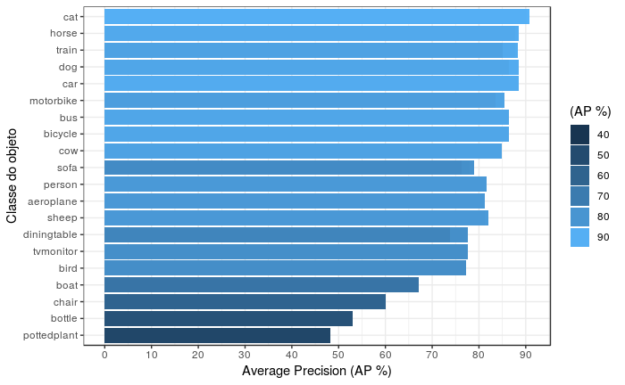

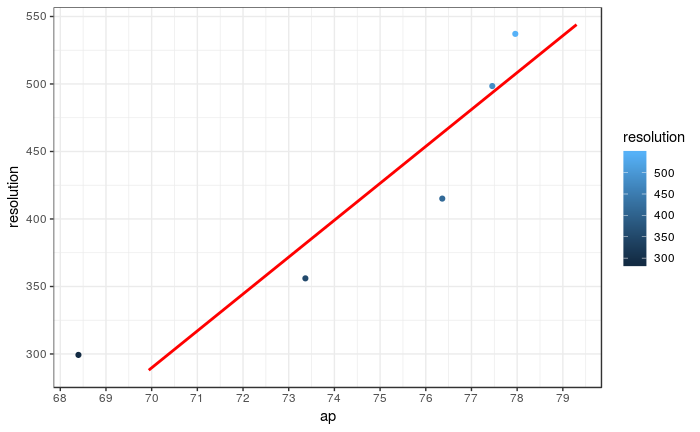

| class_id | class_name | ap | tp | fp | resolution |
| --- | --- | --- | --- | --- | --- |
| 0 | aeroplane | 69.43 | 194 | 113 | 288 |
| 1 | bicycle | 75.30 | 237 | 79 | 288 |
| 2 | bird | 64.77 | 295 | 166 | 288 |
| 3 | boat | 60.67 | 163 | 132 | 288 |
| 4 | bottle | 35.29 | 181 | 160 | 288 |
| 5 | bus | 78.03 | 158 | 68 | 288 |
| 6 | car | 76.52 | 915 | 436 | 288 |
| 7 | cat | 85.88 | 288 | 66 | 288 |
| 8 | chair | 44.82 | 387 | 762 | 288 |
| 9 | cow | 69.43 | 175 | 120 | 288 |

[output cut: 90 more lines]

| pearson | spearman | kendall |
| --- | --- | --- |
| 0.2511095 | 0.3059584 | 0.2321964 |

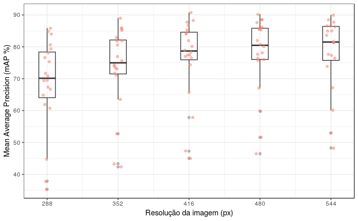

```r
#vetor <- c()
#vetor
```

## Com ICs (288 x 288)

```r
theta_ap = function(d, i){
    aps = d %>%
        filter(resolution == 288) %>%
        slice(i) %>%
        summarise(media_ap = mean(ap))

    fpcc = aps %>% pull(media_ap)

    fpcc
}
theta_c_fds = theta_ap(dados1, 1:NROW(dados1))
theta_c_fds
```

```
[1] 68.273
```

```r
library(boot)
booted <- boot(data = dados1,
               statistic = theta_ap,
               R = 5000)
ci = tidy(booted,
          conf.level = 0.95,
          conf.int = TRUE)
glimpse(ci)
```

```
Observations: 1
Variables: 5
$ statistic <dbl> 68.273
$ bias      <dbl> -0.04769796
$ std.error <dbl> 3.251524
$ conf.low  <dbl> 61.32223
$ conf.high <dbl> 74.28443
```

```r
d288 <- data.frame(res=288, high=ci$conf.high, low=ci$conf.low)
d288
```

| res | high | low |
| --- | --- | --- |
| 288 | 74.28443 | 61.32223 |

## Com ICs (352 x 352)

```r
theta_ap = function(d, i){
    aps = d %>%
        filter(resolution == 352) %>%
        slice(i) %>%
        summarise(media_ap = mean(ap))

    fpcc = aps %>% pull(media_ap)

    fpcc
}
theta_c_fds = theta_ap(dados1, 1:NROW(dados1))
theta_c_fds
```

```
[1] 73.2345
```

```r
library(boot)
booted <- boot(data = dados1,
               statistic = theta_ap,
               R = 5000)
ci = tidy(booted,
          conf.level = 0.95,
          conf.int = TRUE)
glimpse(ci)
```

```
Observations: 1
Variables: 5
$ statistic <dbl> 73.2345
$ bias      <dbl> -0.06485753
$ std.error <dbl> 3.046359
$ conf.low  <dbl> 66.79383
$ conf.high <dbl> 78.77797
```

```r
d352 <- data.frame(res=352, high=ci$conf.high, low=ci$conf.low)
d352
```

| res | high | low |
| --- | --- | --- |
| 352 | 78.77797 | 66.79383 |

## Com ICs (416 x 416)

```r
theta_ap = function(d, i){
    aps = d %>%
        filter(resolution == 416) %>%
        slice(i) %>%
        summarise(media_ap = mean(ap))

    fpcc = aps %>% pull(media_ap)

    fpcc
}
theta_c_fds = theta_ap(dados1, 1:NROW(dados1))
theta_c_fds
```

```
[1] 76.2455
```

```r
library(boot)
booted <- boot(data = dados1,
               statistic = theta_ap,
               R = 5000)
ci = tidy(booted,
          conf.level = 0.95,
          conf.int = TRUE)
glimpse(ci)
```

```
Observations: 1
Variables: 5
$ statistic <dbl> 76.2455
$ bias      <dbl> 0.07122873
$ std.error <dbl> 2.815097
$ conf.low  <dbl> 70.37478
$ conf.high <dbl> 81.44784
```

```r
d416 <- data.frame(res=416, high=ci$conf.high, low=ci$conf.low)
d416
```

| res | high | low |
| --- | --- | --- |
| 416 | 81.44784 | 70.37478 |

## Com ICs (480 x 480)

```r
theta_ap = function(d, i){
    aps = d %>%
        filter(resolution == 480) %>%
        slice(i) %>%
        summarise(media_ap = mean(ap))

    fpcc = aps %>% pull(media_ap)

    fpcc
}
theta_c_fds = theta_ap(dados1, 1:NROW(dados1))
theta_c_fds
```

```
[1] 77.4825
```

```r
library(boot)
booted <- boot(data = dados1,
               statistic = theta_ap,
               R = 5000)
ci = tidy(booted,
          conf.level = 0.95,
          conf.int = TRUE)
glimpse(ci)
```

```
Observations: 1
Variables: 5
$ statistic <dbl> 77.4825
$ bias      <dbl> 0.05941839
$ std.error <dbl> 2.716242
$ conf.low  <dbl> 71.86446
$ conf.high <dbl> 82.60599
```

```r
d480 <- data.frame(res=480, high=ci$conf.high, low=ci$conf.low)
d480
```

| res | high | low |
| --- | --- | --- |
| 480 | 82.60599 | 71.86446 |

## Com ICs (544 x 544)

```r
theta_ap = function(d, i){
    aps = d %>%
        filter(resolution == 544) %>%
        slice(i) %>%
        summarise(media_ap = mean(ap))

    fpcc = aps %>% pull(media_ap)

    fpcc
}
theta_c_fds = theta_ap(dados1, 1:NROW(dados1))
theta_c_fds
```

```
[1] 77.855
```

```r
library(boot)
booted <- boot(data = dados1,
               statistic = theta_ap,
               R = 5000)
ci = tidy(booted,
          conf.level = 0.95,
          conf.int = TRUE)
glimpse(ci)
```

```
Observations: 1
Variables: 5
$ statistic <dbl> 77.855
$ bias      <dbl> 0.0242257
$ std.error <dbl> 2.685427
$ conf.low  <dbl> 72.20325
$ conf.high <dbl> 82.75364
```

```r
d544<- data.frame(res=544, high=ci$conf.high, low=ci$conf.low)
d544
```

| res | high | low |
| --- | --- | --- |
| 544 | 82.75364 | 72.20325 |

```r
rmax <- c(d288$high, d352$high, d416$high, d480$high, d544$high)
rmin <- c(d288$low, d352$low, d416$low, d480$low, d544$low)
rmax
```

```
[1] 74.28443 78.77797 81.44784 82.60599 82.75364
```

```r
rmin
```

```
[1] 61.32223 66.79383 70.37478 71.86446 72.20325
```

O processo nesta seção tem como objetivo chegar a afirmações sobre as imagens em geral, a partir da amostra coletada. Para isto, utilizou-se o método para gerar 5000 reamostragens e posteriormente realizar as devidas análises estatísticas.

Deseja-se analisar o impacto do tamanho da resolução das imagens sob a taxa de AP. Desta forma, comparou-se a diferença entre a menor, a média e a maior das resoluções apresentadas, isto é, as resoluções 288 $\times$ 288, 416 $\times$ 416 e 544 $\times$ 544. A figura 5 mostra a relação entre as taxas de AP e as todas as resoluções abordadas neste trabalho, contendo os respectivos intervalos de confiança e a média geral da taxa de AP.

| ap |
| --- |
| 74.62 |

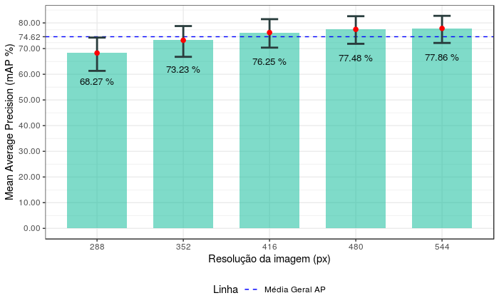

Com 95% de confiança, a partir da nossa amostra de tamanho 100, os valores localizados dentro deste intervalo são listados abaixo:

Para a resolução 352 $\times$ 352 foi obtida um valor de 73.23 para o $\hat{\theta}$ e um intervalo de confiança de [66.95, 78.73]. (desv. padrão 2,99, N = 20)

Para a resolução 544 $\times$ 544 foi obtida um valor de 77.85 para o $\hat{\theta}$ e um intervalo de confiança de [72.20, 82.68]. (desv. padrão 2.66, N = 20)

Diferença entre as médias de AP entre as resoluções 288 $\times$ 288 e 416 $\times$ 416 obtiveram um valor de 7.97 com um intervalo de confiança de [95.0% CI -0.311, 16.2] Com 95% de confiança, a partir da amostra de dados analisada, pode-se estimar que para a população, que de acordo com comparação entre as taxas de AP entre as resoluções 288 $\times$ 288 e 416 $\times$ 416 que pode existir uma diferença muito pequena positiva para a resolução 416 $\times$ 416 ou até mesmo não existir, mas caso exista, trata-se de uma diferença com efeito relevante.

Diferença entre as médias de AP entre as resoluções 544 $\times$ 544 e 416 $\times$ 416 obtiveram um valor de 1.61 com um intervalo de confiança de [95.0% CI -5.8, 9.14]. Com 95% de confiança, a partir da amostra de dados analisada, pode-se estimar que para a população, que de acordo com comparação entre as taxas de AP entre as resoluções 544 $\times$ 544 e 416 $\times$ 416 que pode existir uma diferença muito pequena positiva para a resolução 544 $\times$ 544 ou até mesmo não existir, mas caso exista, não tem-se evidência de que seja importante, mas com um efeito menor que a comparação entre as resoluções 288 $\times$ 288 e 416 $\times$ 416.

Diferença entre as médias de AP entre as resoluções 544 $\times$ 544 e 288 $\times$ 288 obtiveram um valor de 9.58 com um intervalo de confiança de [95.0% CI 1.71, 17.6] Com 95% de confiança, a partir da amostra de dados analisada, pode-se estimar que para a população, que de acordo com comparação entre as taxas de AP entre as resoluções 544 $\times$ 544 e 288 $\times$ 288 que pode existir uma diferença muito pequena positiva para a resolução 544 $\times$ 544 e com evidência de que seja importante, mas com um efeito maior que a comparação entre as resoluções 288 $\times$ 288 e 416 $\times$ 416 e, 544 $\times$ 544 e 288 $\times$ 288.

Deste modo, dada a análise dos intervalos de confiança, pode-se estimar que o tamanho da resolução aparenta causar um efeito positivo na taxa de AP atingida na amostra coletada. E, que de acordo com o coeficiente de Pearson, a correlação entre a resolução da imagem e o valor de da amostra é de $0,25$, isto é, existe uma correlação fraca e positiva entre as duas variáveis.

Portanto, como proposta de trabalhos futuros e no intuito de alcançar resultados mais precisos, é fundamental ser feita uma reanálise utilizando um conjunto de dados maior de resoluções de imagens.